# HW5_TimeSeries

Sajjad Rezvani

3/24/2022

## Question 1: data set `milk` U.S. milk production (in millions of pounds) from January, 1994 to December, 2005

### 1.a. Construct a time series plot

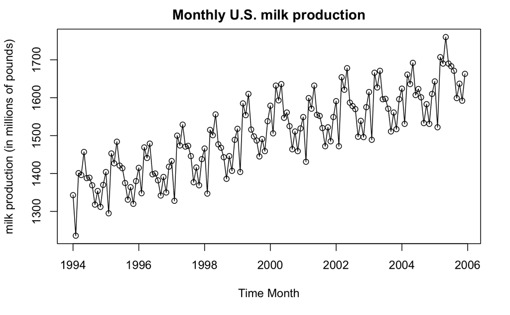

```r
library(TSA)
data(milk)
plot(milk, ylab="milk production (in millions of pounds)",xlab="Time Month",type="o",
     main="Monthly U.S. milk production")
```

**Conclusion**  
We can see that there is an increasing trend in the plot but the variance seems to be constant. Also, seasonality pattern can be seen.

### 1.b. Plot the first differences

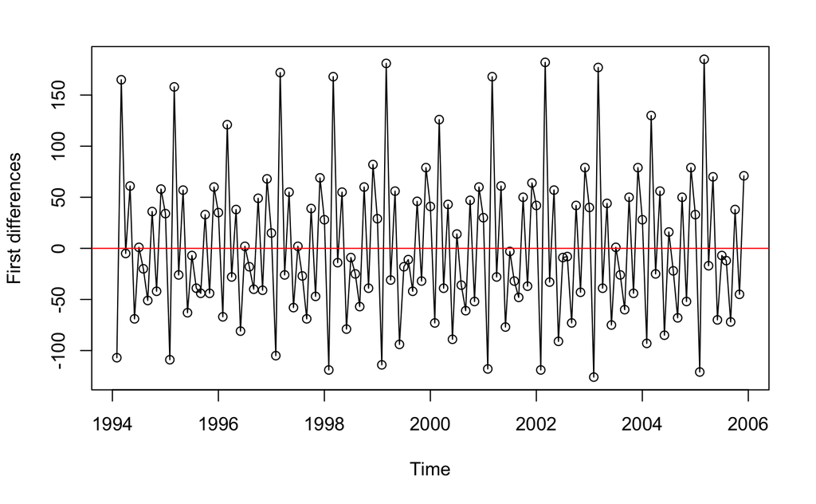

```r
plot(diff(milk),ylab="First differences",xlab="Time",type="o")
abline(h=0, col = "red")
```

**Comparison**  
So,According to the first differences plot as indicated above:  
- Increasing trend is no longer available.  
- However,there is still seasonal trend in the plot.

### 1.c. Model diagnostic and checking if data differences resemble a normal zero mean white noise process

```r
diff_milk = diff(milk)
data.month = season(diff_milk)
model.milk = lm(diff_milk ~ data.month-1)
summary(model.milk)
```

```
Call:
lm(formula = diff_milk ~ data.month - 1)

Residuals:
    Min      1Q  Median      3Q     Max
-40.083  -7.250   0.333   6.917  38.917

Coefficients:
                    Estimate Std. Error t value Pr(>|t|)
data.monthJanuary     32.273      3.640   8.866 4.79e-15 ***
data.monthFebruary  -105.917      3.485 -30.390  < 2e-16 ***
data.monthMarch      161.083      3.485  46.219  < 2e-16 ***
data.monthApril      -25.917      3.485  -7.436 1.21e-11 ***
data.monthMay         54.417      3.485  15.613  < 2e-16 ***
data.monthJune       -77.583      3.485 -22.261  < 2e-16 ***
data.monthJuly        -1.417      3.485  -0.406    0.685
data.monthAugust     -23.000      3.485  -6.599 9.33e-10 ***
data.monthSeptember  -57.083      3.485 -16.379  < 2e-16 ***
data.monthOctober     45.000      3.485  12.912  < 2e-16 ***
data.monthNovember   -43.167      3.485 -12.386  < 2e-16 ***
data.monthDecember    70.667      3.485  20.276  < 2e-16 ***
---
Signif. codes:  0 ‘***’ 0.001 ‘**’ 0.01 ‘*’ 0.05 ‘.’ 0.1 ‘ ’ 1

Residual standard error: 12.07 on 131 degrees of freedom
Multiple R-squared:  0.9743,    Adjusted R-squared:  0.972
F-statistic: 414.7 on 12 and 131 DF,  p-value: < 2.2e-16
```

#### plot the fitting

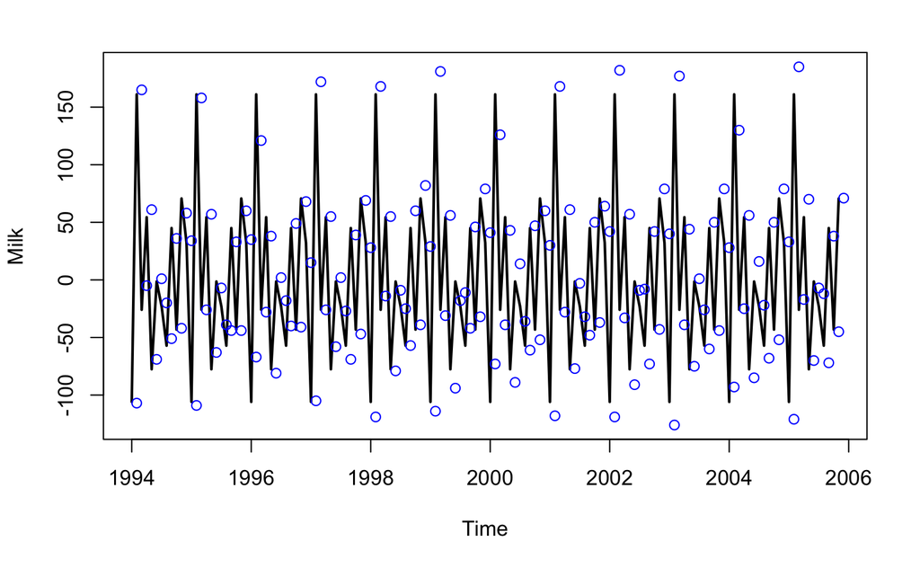

```r
plot(ts(fitted(model.milk), freq=12, start=1994), ylab="Milk", xlab="Time", type="l",
ylim=range(c(fitted(model.milk),diff_milk)),lwd=2)
points(diff_milk,col="blue")
```

#### Histogram and qq plot

```r
par(mfrow=c(1,2))
hist(diff_milk,main="Histogram of the first Diff",xlab="First Difference")
qqnorm((diff_milk),main="QQ plot")
```

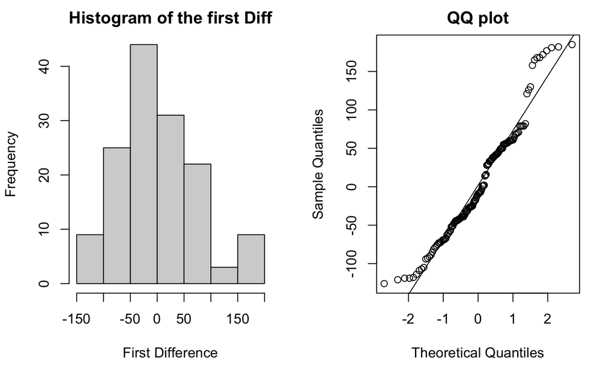

```r
qqline((diff_milk),main="QQ plot")
```

**Conclusion**  
- According to the QQ plot the first differencing order of the our data is not normally distributed, since a lot of points do not fall on the straight line.  
- Based on the his plot the data is right skewed.

#### Shapiro-Wilk test for normality

```r
shapiro.test((diff_milk))
```

```
    Shapiro-Wilk normality test

data:  (diff_milk)
W = 0.95809, p-value = 0.0002411
```

**Conclusion**  
Based on the Shapiro Test the data does not follow a normal distribution, since the p value is so small and we reject the null hypothesis.

#### Runs test for independence

```r
runs((diff_milk))
```

```
$pvalue
[1] 5.73e-10

$observed.runs
[1] 108

$expected.runs
[1] 71.90909

$n1
[1] 78

$n2
[1] 65

$k
[1] 0
```

**Conclusion**  
The difference process is not independent since the p value is so small and the null hypothesis will be rejected.Also, there is big difference between expected number of runs and observed number of runs that indicates difference process is not independent.

#### ACF

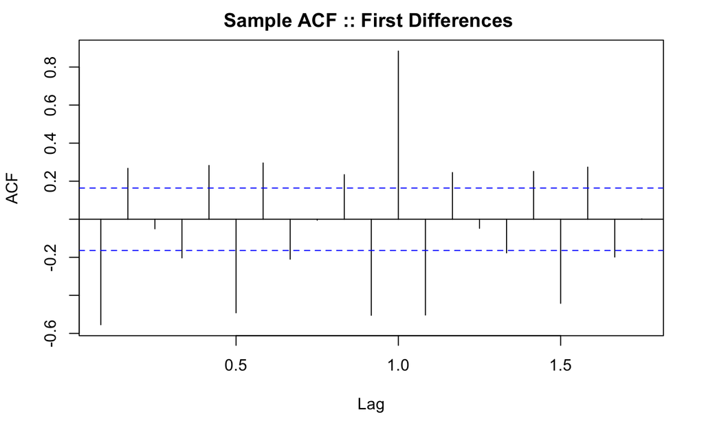

```r
acf(diff_milk,main="Sample ACF :: First Differences ")
```

**Conclusion**  
Note that many of the sample estimates $r^*_k$ fall outside the $\frac{±2}{\sqrt n}$ margin of error cutoff. So the differences process likely `do not resemble a white noise process`.

## Question 2 : Use R to simulate the AR(1) process Yt = et + 0.4Yt−1, where n = 200, and et ∼ iid N(0,1). The series Wt are generated by Wt = exp(Yt). Use set.seed(1) to generate the time series Yt.

### 2.0. generate the time series $Y_t$

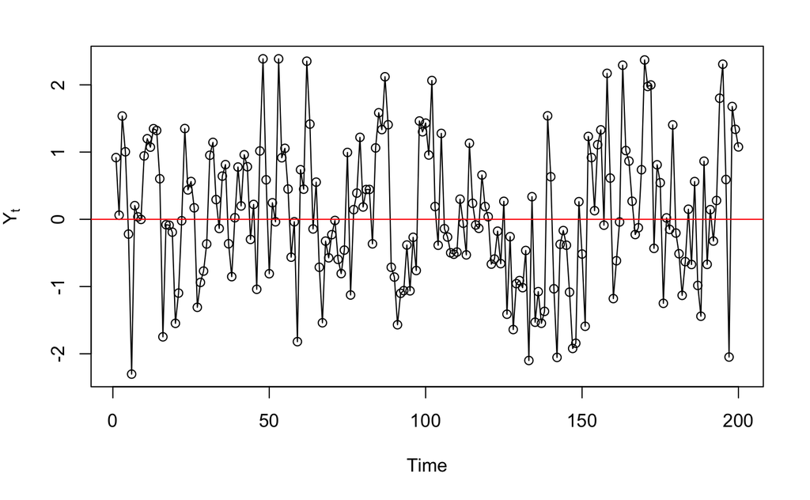

```r
set.seed(1)
ar1.sim <- arima.sim(list(order = c(1,0,0), ar = 0.4), n = 200)
plot(ar1.sim,ylab=expression(Y[t]),xlab="Time",type="o")
abline(h = 0, col = "red")
```

### 2.a. the time series plot and sample ACF for the series $W_t$

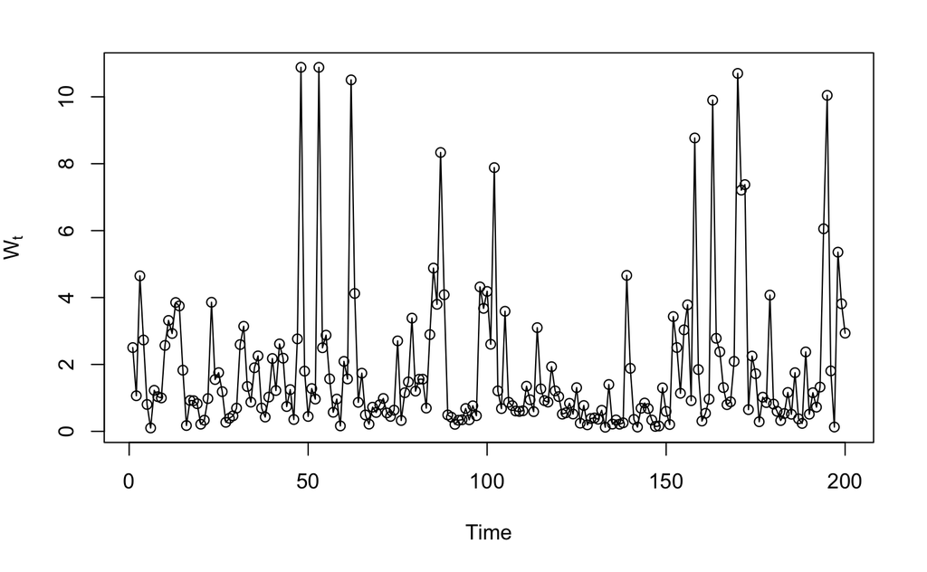

```r
w_t= exp(ar1.sim)
plot(w_t, ylab=expression(W[t]),xlab="Time",type="o")
```

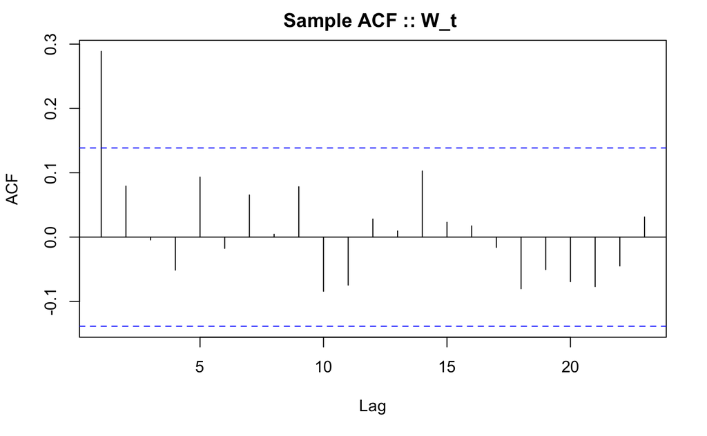

```r
acf(w_t,main="Sample ACF :: W_t ")
```

### 2.b. BoxCox.ar

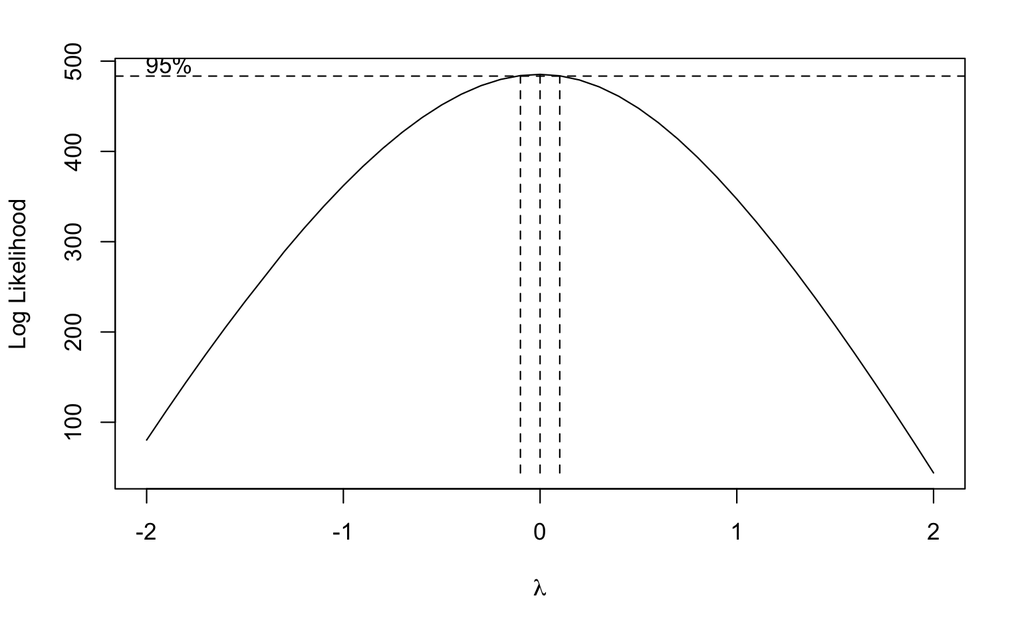

```r
BoxCox.ar(w_t)
```

**Conclusion**  
Based ob Box Cox the best value for $\lambda$ is zero which means that the best transformation is log transformation.

### 2.c. Transformation

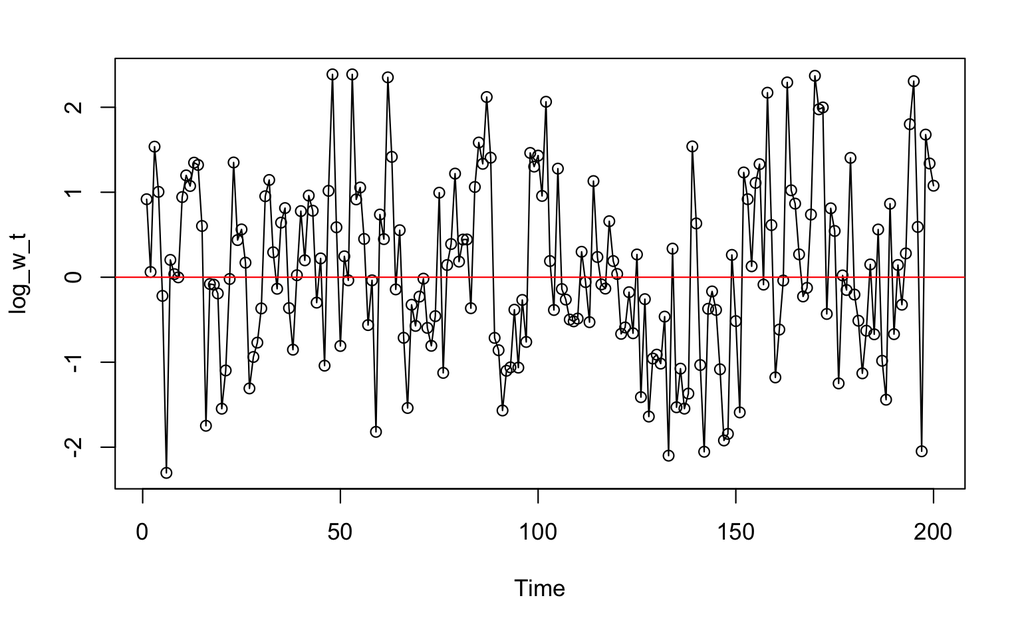

```r
log_w_t = log(w_t)
plot(log_w_t,ylab="log_w_t",xlab="Time",type="o")
abline(h= 0, col="red")
```

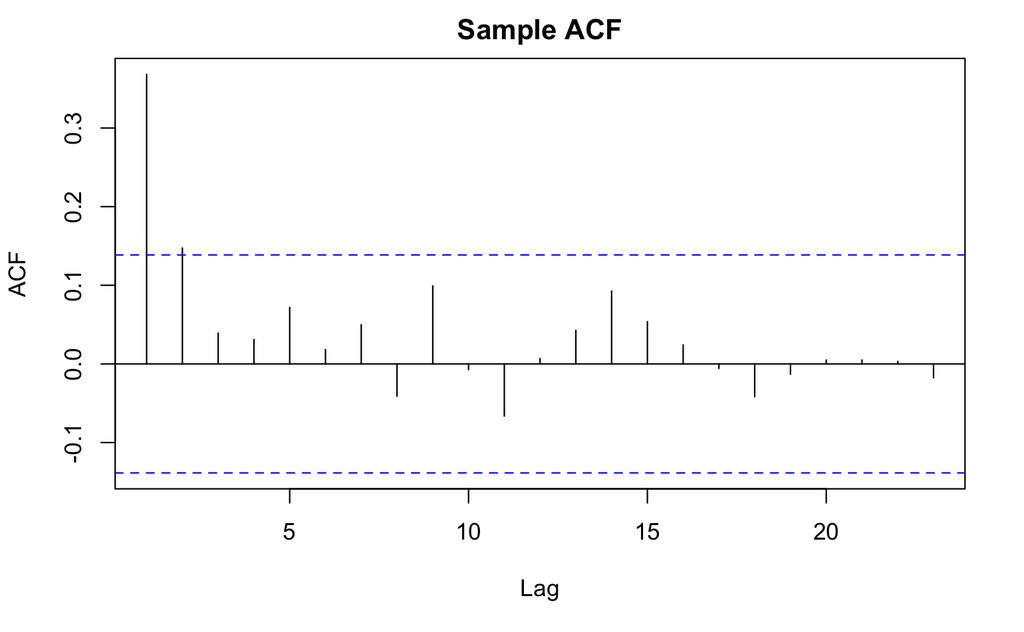

```r
acf(log_w_t,main="Sample ACF")
```

**Conclusion**  
According to the ACF plot most of the sample estimates $r^*_k$ fall inside the $\frac{±2}{\sqrt n}$ margin of error cutoff. So the log-transformation likely `resemble a white noise process`. Also, log-transformation is similar to the MA(1).